# Naive Bayes

Jeffrey Arnold

2018-04-05

## Naive Bayes

Bayes’ theorem can almost immediately be supervised classification algorithms. The Naive Bayes classifiers are a family of classifiers which apply Bayes’ Rule to classify a discrete response $y$ using observed features $(x_1, \dots, x_K)$, with a simplifying assumption of independence.

Suppose that $y$ is the class of an observation; i.e., it is a discrete variable taking values $j \in 1, \dots, J$. Suppose that $(x_1, \dots, x_k)$ is a vector of $K$ observed features (predictors) for an observation. These can be discrete or continuous. We are interested in the probabilities of each class after having observed its features, which we can reformulate in Bayes’ rule.
$$p(y | x_1, \dots, x_k) = \frac{p(x_1, \dots, x_k | y) p(y)}{\sum_{j = 1}^{J} p(x_1, \dots, x_k | y = j) p(y = j)}$$

The “naive” modifier in “naive Bayes” comes from an additional asumption that distributions of features are independent conditional on the class,
$$p(x_k | y, x_1, \dots, x_K) = p(x_k | y)$$
for all $k \in 1, \dots, K$. This independence is a strong one, but will make this problem much more tractable. It is much easier to model and estimate the univariate $p(x_k | y)$ probabilities, but much harder to model and estimate a $K$-variate distribution, $p(x_1, \dots, x_K | y)$.

Using independence, we can rewrite the posterior distribution as,
$$p(y | x_1, \dots, x_k) = \frac{p(y) p(x_1 | y) \cdots p(x_K | y)}{\sum_{j = 1}^{J} p(y) p(x_1 | y) \cdots p(x_K | y)} = \frac{p(y) \prod_{k = 1}^K p(x_k | y)}{\sum_{j = 1}^{J} p(y) \prod_{k = 1}^K p(x_k | y)} .$$

Moreover, often interested in the most likely class, where we can ignore the marginal likelihood,
$$\begin{aligned}[t]
\arg\max_{j \in 1, \dots, J} p(y = j | x_1, \dots, x_k) &= \frac{p(y = j) \prod_{k = 1}^K p(x_k | y = j)}{\sum_{j = 1}^{J} p(y = j) \prod_{k = 1}^K p(x_k | y = j)} \\
&\propto p(y = j) \prod_{k = 1}^K p(x_k | y = j) .
\end{aligned}$$

In applying naive Bayes, there are two choices that need to be made:

1. probability distributions for likelihood of each feature, $p(x_i | y)$, and
2. prior distribution $p(y)$ .

After choosing the distributional forms of $p(y)$, $p(x_1 | y)$, …, $p(x_K | y)$ appropriate for your model, the workflow is,

1. Train your model on data ($x_1, \dots, x_k$, $y$) to estimate the distributions $\hat{p}(y)$, $\hat{p}(x_1 | y)$, …, $\hat{p}(x_K | y)$.
2. For new observations, calculate $p(y | x)$ using the learned parameters of the distribution.
3. Evaluate the model using predictive criteria.

## Federalist Papers

In an early example of empirical Bayesian statistics and computational NLP, F. Mosteller and D. L. Wallace used naive Bayes to classify the disputed articles and conclude that there is strong evidence to suggest that Madison wrote all the disputed articles.

This example will use the following libraries.

```r
library("corpus")
library("tidyverse")
```

The file `federalist.csv` contains word counts of 70 function words used by Mosteller and Wallace in their analysis, as well as the count of “-OTHER-” (a count of all other tokens, including words and punction, in the document).

```r
federalist <- read_csv("federalist.csv", na = "")
```

We have $D$ documents. Let $y \in Y = \{\text{Hamilton}, \text{Madison} \}$ be the author of each document. We want to infer the probability of an author given that
$$p(y | d) = \frac{p(d | y) p(y)}{\sum_{y \in Y} p(d | y) p(y)} .$$
The next question is how to represent and model documents, meaning which features we should use and the distribution we should use for those.

Suppose that each document can be represented as a vector of word counts. Suppose that each document is represented as a vector of word counts. Suppose that the vocabularly in the corpus consists of $K$ distinct words, e.g. “a”, “an”, …. Each document can be represented as $(w_1, \dots, w_K)$, where $w_k$ is the counts of word $k$ in the document. Let $N_d = \sum_{k = 1}^K w_k$ be the total number of words in document $d$. Then conditional probability of a document given its class can be modeled as a multinomial distribution,
$$p(d | y) = \mathrm{Multinomial}(y; \theta_1, \dots, \theta_K, N_d) = \frac{N_d!}{w_1!\cdots w_K!} \theta_1^{w_1} \cdots \theta_K^{w_K}$$
where $\theta_k \in 1, \dots, K$ is the probability that word $k$ occurs. The values that we will be interested in calculating are $\hat{\theta}_1, \dots, \hat{\theta}_K$.

For a corpus, we can calculate these parameters with the maximum a posteriori estimator,
$$\hat{\theta}_{k,y = j} = \frac{\sum_{d \in D_j} w_{k,d} + 1}{\sum_{d \in D_j} N_d + V} =$$
The estimator $\hat{\theta}_{k,y}$ is the fraction of times that word $k$ appears among all words in all documents in a category.

For the priors $p(y)$ we will use the proportion of documents in each class,
$$\hat{\gamma}_j = p(y = j) = \frac{D_j}{D}$$
The value of $\hat{\gamma}$ is the fraction of documents in category $j$ to all documents.

```r
p_words_author <- federalist %>%
  # keep only Hamilton and Madison
  filter(author %in% c("Hamilton", "Madison")) %>%
  # count terms used by each author
  group_by(author, term) %>%
  summarise(count = sum(count)) %>%
  ungroup() %>%
  # calculate p(w | c) for each author
  group_by(author) %>%
  mutate(p = (count + 1) / sum(count + 1))
```

Create the proportion of documents associated with each author.

```r
p_author <- federalist %>%
  filter(author %in% c("Hamilton", "Madison")) %>%
  count(author) %>%
  mutate(p = n / sum(n))
p_author
```

```
## # A tibble: 2 x 3
##     author     n         p
##      <chr> <int>     <dbl>
## 1 Hamilton  3621 0.7846154
## 2  Madison   994 0.2153846
```

Use Bayes’ rule to find the posterior probability of each document:

```r
post <- p_words_author %>%
  select(author, term, p) %>%
  # don't include author.
  left_join(select(federalist, text, term, count), by = c("term")) %>%
  group_by(author, text) %>%
  arrange(author, text, term) %>%
  summarise(p_words_author = dmultinom(count, prob = p))
```

Posterior distributions.

```r
posterior <- left_join(post,
                  select(p_author, author, p_author = p),
                  by = "author") %>%
  mutate(p_author_words = p_words_author * p_author) %>%
  # normalize to probabilities
  group_by(text) %>%
  mutate(p_author_words = p_author_words / sum(p_author_words))
```

Find the most probable document:

```r
predictions <- posterior %>%
  select(author, text, p_author_words) %>%
  # For each document, choose the author with the highest probability:
  group_by(text) %>%
  arrange(text, desc(p_author_words)) %>%
  slice(1) %>%
  rename(pred = author)
```

Actual authors of the Federalist papers:

```r
authors <- select(federalist, text, author) %>%
  group_by(text) %>%
  slice(1)
```

Add actual authors to predictions in order to evaluate this:

```r
predictions <- left_join(predictions, authors, by = "text") %>%
  mutate(author = if_else(is.na(author), "Unknown", author)) %>%
  filter(author != "Jay") %>%
  mutate(p_hamilton = if_else(pred == "Hamilton", p_author_words,
                              1 - p_author_words))
```

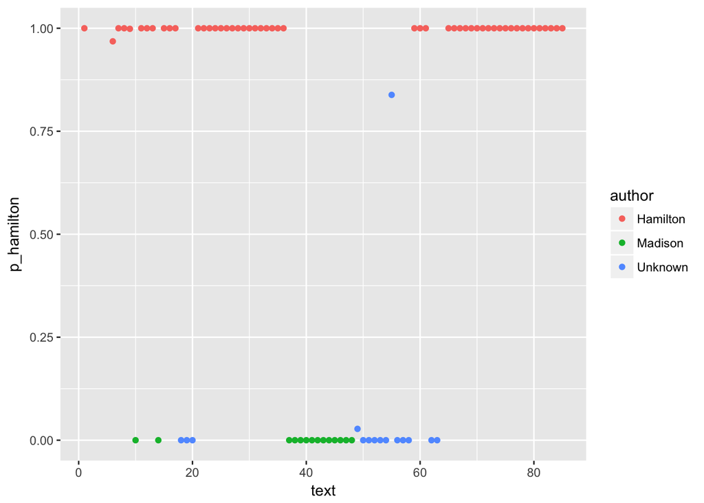

```r
ggplot(predictions, aes(x = text, colour = author, y = p_hamilton)) +
  geom_point()
```

## References

- Scikit-Learn, [Naive Bayes](http://scikit-learn.org/stable/modules/naive_bayes.html#multinomial-naive-bayes)
- Harry Zhang (2004) [The Optimality of Naive Bayes](http://www.cs.unb.ca/~hzhang/publications/FLAIRS04ZhangH.pdf).
- Jurafsky slides on [Text Classification and Naive Bayes](https://web.stanford.edu/class/cs124/lec/naivebayes.pdf)